# Lab 1: Introduction – solution

If you have not already done so, you’ll need to start R and load the `spatstat` package by typing

```r
library(spatstat)
```

### Exercise 1

We will study a dataset that records the locations of Ponderosa Pine trees (*Pinus ponderosa*) in a study region in the Klamath National Forest in northern California. The data are included with `spatstat` as the dataset `ponderosa`.

1. assign the data to a shorter name, like `X` or `P`;

   To assign the data to `X` we simply write:

   ```r
   X <- ponderosa
   ```

2. plot the data;

   To plot the data we do the following:

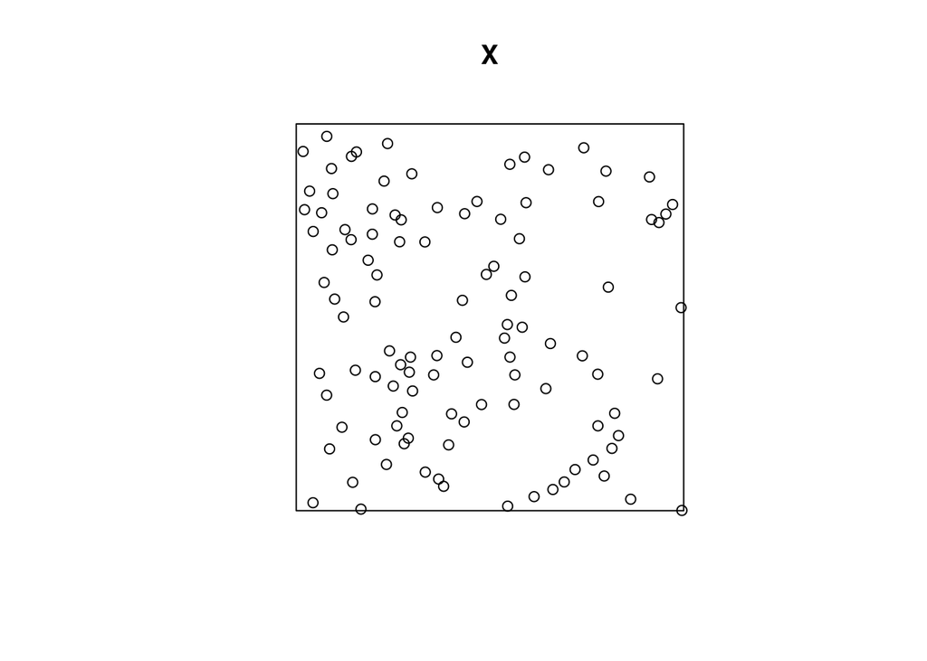

   ```r
   plot(X)
   ```

   Both `npoints` and `print.ppp` displays the number of recorded trees:

   ```r
   npoints(X)
   ```

   ```
   ## [1] 108
   ```

   ```r
   print(X)
   ```

   ```
   ## Planar point pattern: 108 points
   ## window: rectangle = [0, 120] x [0, 120] metres
   ```

   I.e. there are 108 trees in the dataset.
4. find the dimensions of the study region;

   The dimensions of the observation window can be seen above. Alternatively, it can be directly assesed via

   ```r
   Window(X)
   ```

   ```
   ## window: rectangle = [0, 120] x [0, 120] metres
   ```

5. obtain an estimate of the average intensity of trees (number of trees per unit area).

   The average intensity can be computed via `intensity.ppp`

   ```r
   intensity(X)
   ```

   ```
   ## [1] 0.0075
   ```

   or the more expansive `summary.ppp`:

   ```r
   summary(X)
   ```

   ```
   ## Planar point pattern:  108 points
   ## Average intensity 0.0075 points per square metre
   ##
   ## Coordinates are given to 3 decimal places
   ## i.e. rounded to the nearest multiple of 0.001 metres
   ##
   ## Window: rectangle = [0, 120] x [0, 120] metres
   ## Window area = 14400 square metres
   ## Unit of length: 1 metre
   ```

### Exercise 2

The Ponderosa data, continued:

1. When you type `plot(ponderosa)`, the command that is actually executed is `plot.ppp`, the plot method for point patterns. Read the help file for the function `plot.ppp`, and find out which argument to the function can be used to control the main title for the plot;

   From the documentation, the argument that controls the title is `main` as is also the case in the regular generic `plot`.
2. plot the Ponderosa data with the title *Ponderosa Pine Trees* above it;

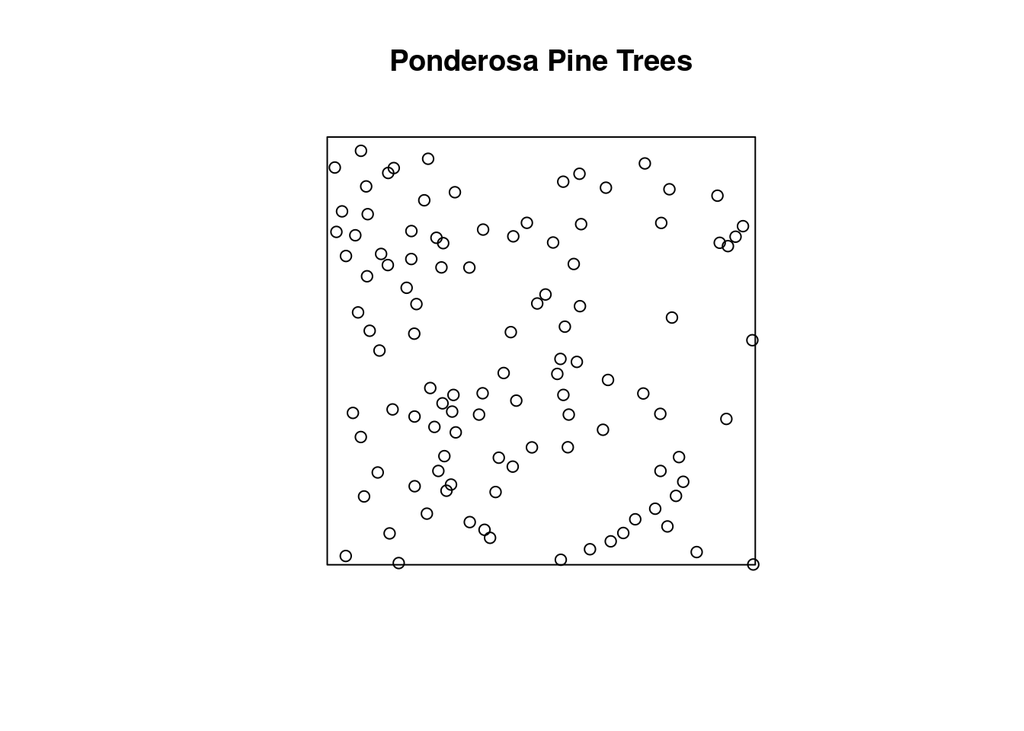

   ```r
   plot(ponderosa, main = "Ponderosa Pine Trees")
   ```

3. from your reading of the help file, predict what will happen if we type

   ```r
   plot(ponderosa, chars="X", cols="green")
   ```

   then check that your guess was correct;

   Each point will be plotted as an green “X” and indeed:

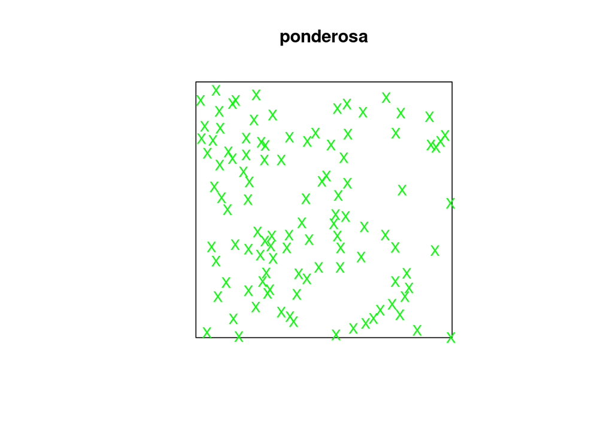

   ```r
   plot(ponderosa, chars="X", cols="green")
   ```

4. try different values of the argument `chars`, for example, one of the integers 0 to 25, or a letter of the alphabet. (Note the difference between `chars=3` and `chars="+"`, and the difference between `chars=4` and `chars="X"`).

   There are subtle differences in the actual character/point types plotted. When given a string literal, the actual character is plotted as the point type.

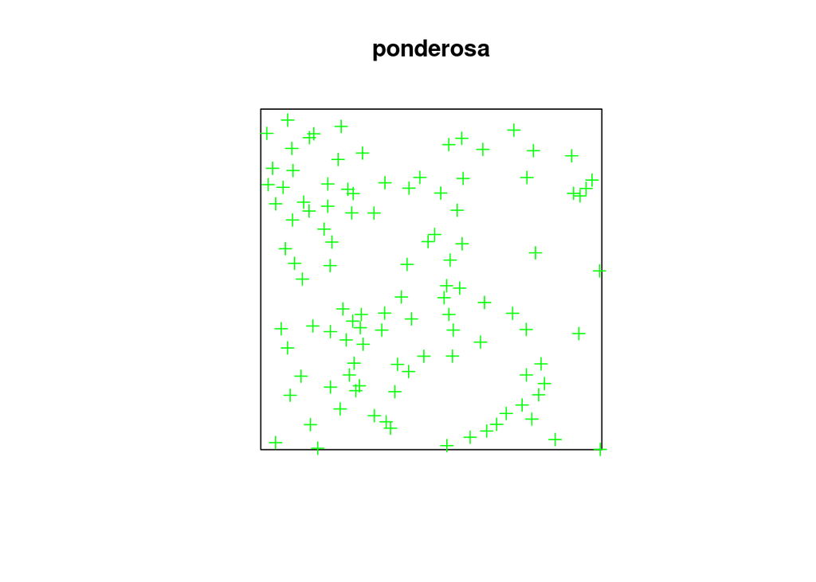

   ```r
   plot(ponderosa, chars=3, cols="green")
   ```

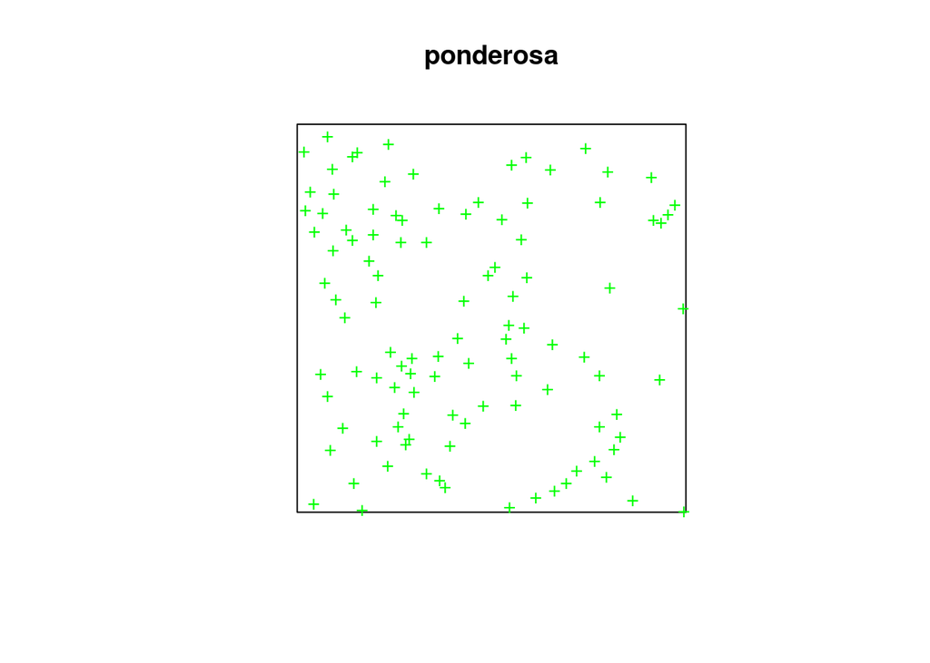

   ```r
   plot(ponderosa, chars="+", cols="green")
   ```

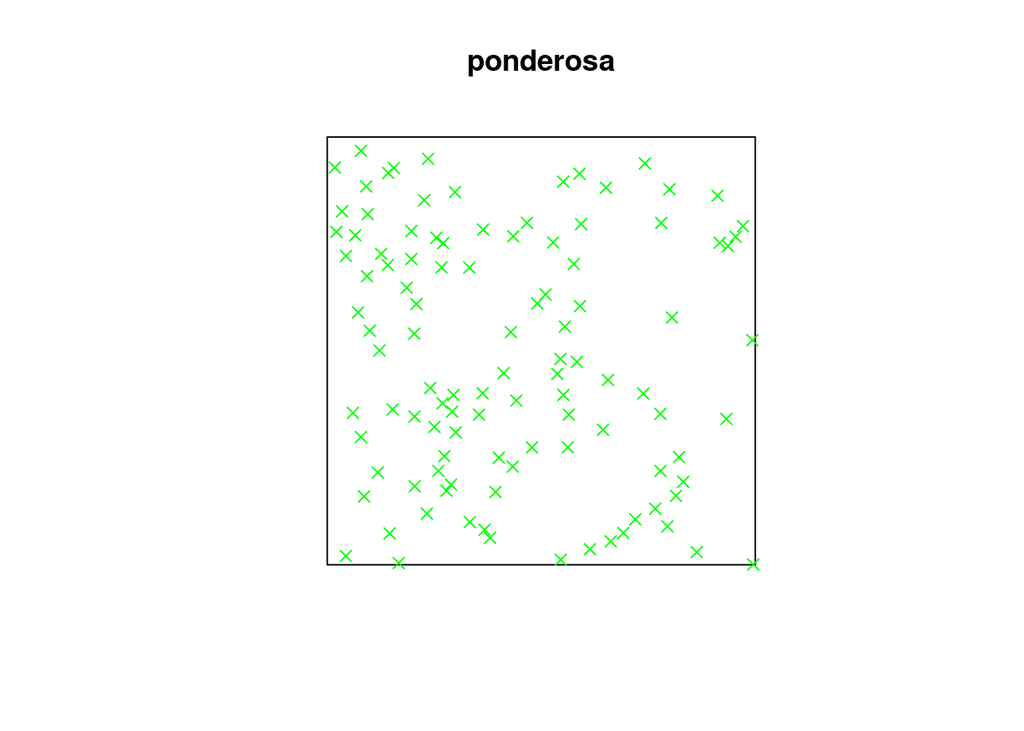

   ```r
   plot(ponderosa, chars=4, cols="green")
   ```

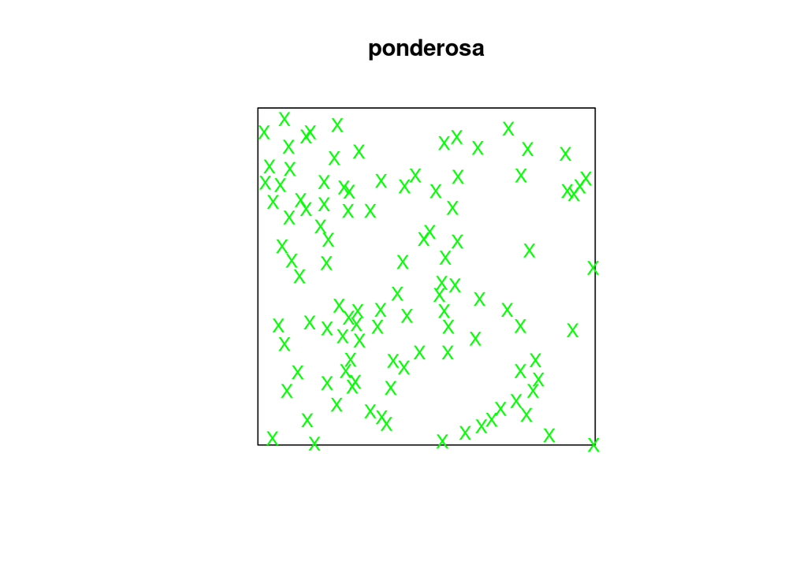

   ```r
   plot(ponderosa, chars="X", cols="green")
   ```

### Exercise 3

The dataset `japanesepines` contains the locations of Japanese Black Pine trees in a study region.

1. Plot the `japanesepines` data.

   We use the generic `plot` function which is dispatched to `plot.ppp`:

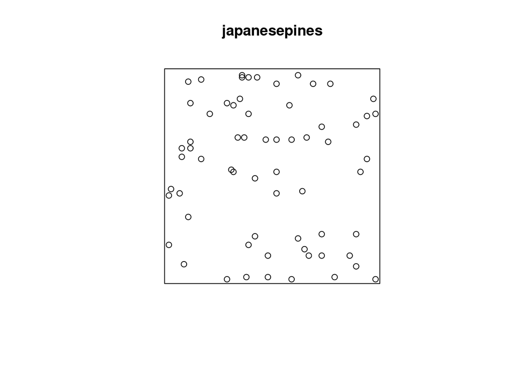

   ```r
   plot(japanesepines)
   ```

2. What is the average intensity (the average number of points per unit area?

   The average intensity can be computed via `intensity.ppp`:

   ```r
   intensity(japanesepines)
   ```

   ```
   ## [1] 65
   ```

3. Using `density.ppp`, compute a kernel estimate of the spatially-varying intensity function for the Japanese pines data, using a Gaussian kernel with standard deviation $\sigma=0.1$ units, and store the estimated intensity in an object `D` say.

   From the documentation (`?density.ppp`) we see that the following will work:

   ```r
   D <- density(japanesepines, sigma = 0.1)
   ```

4. Plot a colour image of the kernel estimate `D`.

   The plotting of the colour image is automatically done by dispatched call to the `plot.im` method by calling `plot` on the `im` object.

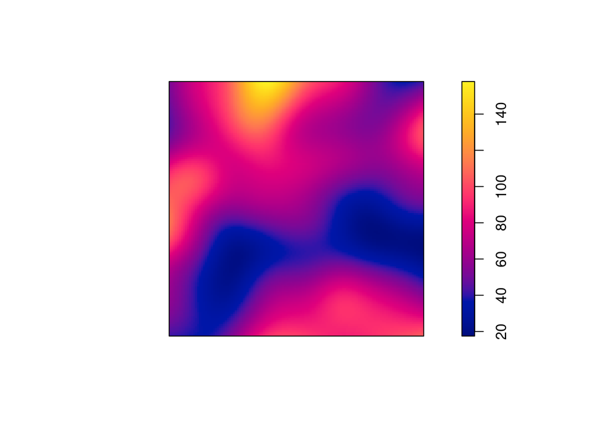

   ```r
   plot(D, main = "")
   ```

5. Most plotting commands will accept the argument `add=TRUE` and interpret it to mean that the plot should be drawn over the existing display, without clearing the screen beforehand. Use this to plot a colour image of the kernel estimate `D` with the original Japanese Pines data superimposed.

   We can use the `add = TRUE` functionality of the plotting methods.

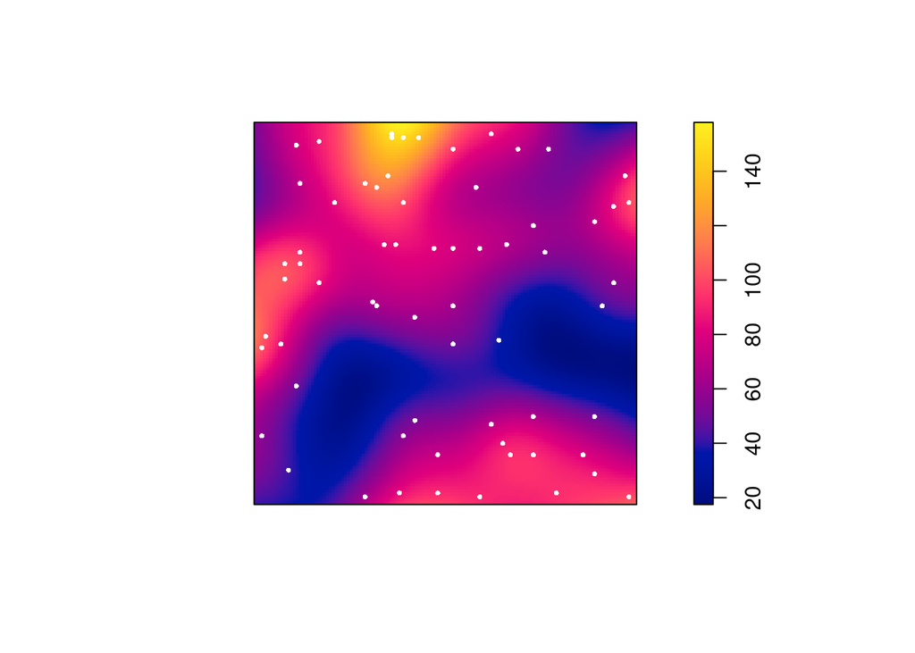

   ```r
   plot(D, main = "")
   plot(japanesepines, add = TRUE, cols = "white", cex = 0.5, pch = 16)
   ```

6. Plot the kernel estimate without the ‘colour ribbon’.

   From `help("plot.im")` we see that `ribbon = FALSE` disables the colour key:

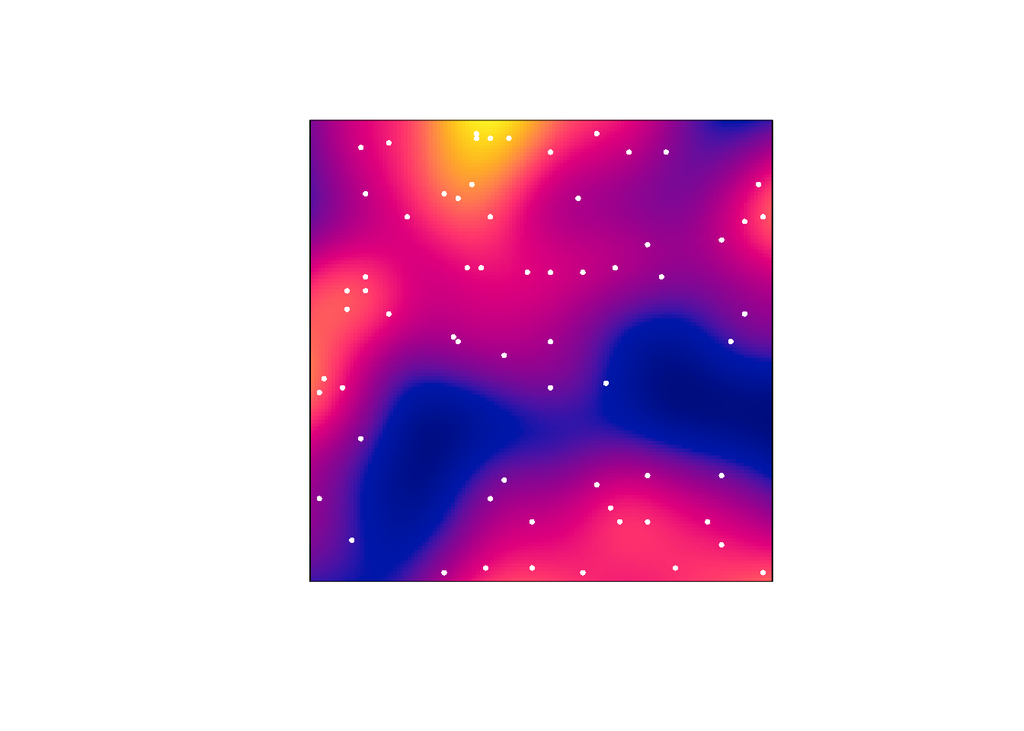

   ```r
   plot(D, main = "", ribbon = FALSE)
   plot(japanesepines, add = TRUE, cols = "white", cex = 0.5, pch = 16)
   ```

7. Try the following command

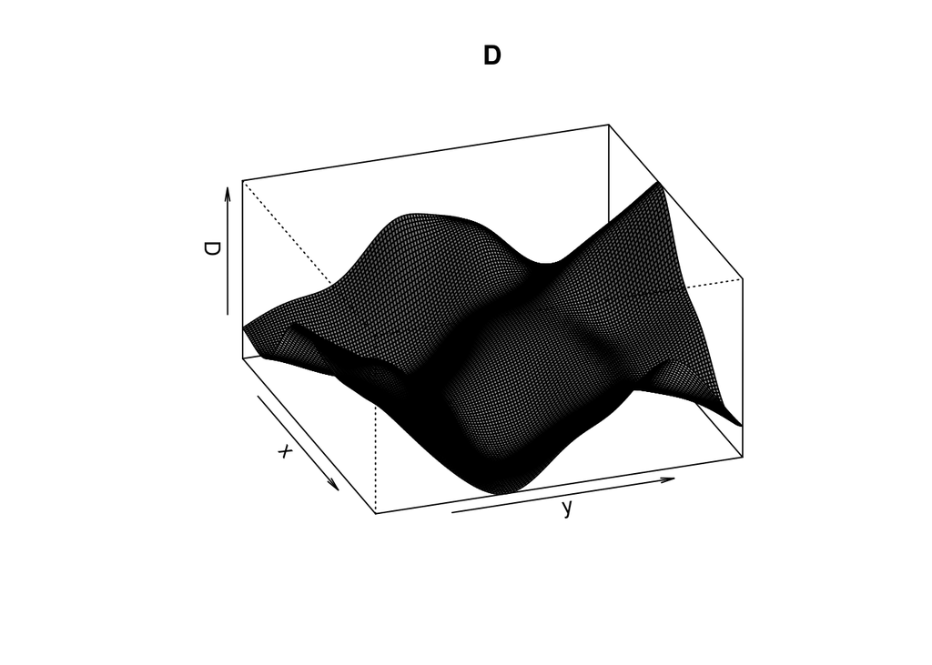

   ```r
   persp(D, theta=70, phi=25, shade=0.4)
   ```

   and find the documentation for the arguments `theta`, `phi` and `shade`.

   It dispatches to `persp.im`, but these arguments are then passed down to `persp.default` through the dots (`...`). From the documentation of `persp.default` they are “angles defining the viewing direction. `theta` gives the azimuthal direction and `phi` the colatitude.” The `shade` controls the shading of the surface facets.

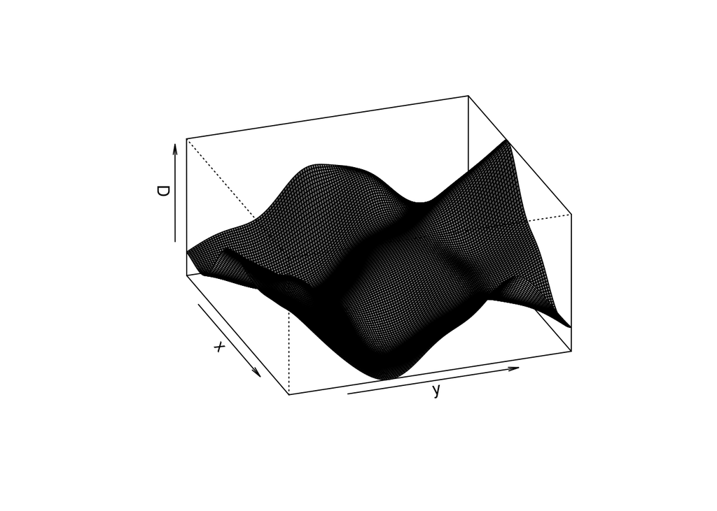

   ```r
   persp(D, theta=70, phi=25, shade=0.4, main = "")
   ```

8. Find the maximum and minimum values of the intensity estimate over the study region. (Hint: Use `summary` or `range`)

   ```r
   range(D)
   ```

   ```
   ## [1]  17.47221 157.95229
   ```

9. The kernel estimate of intensity is defined so that its integral over the entire study region is equal to the number of points in the data pattern, ignoring edge effects. Check whether this is approximately true in this example. (Hint: use `integral`)

   Calling `integral.im` we see that the integral is close to the observed number of points 65:

   ```r
   round(integral(D))
   ```

   ```
   ## [1] 64
   ```

### Exercise 4

The dataset `hamster` is a multitype pattern representing the locations of cells of two types, *dividing* and *pyknotic*.

1. plot the pattern;

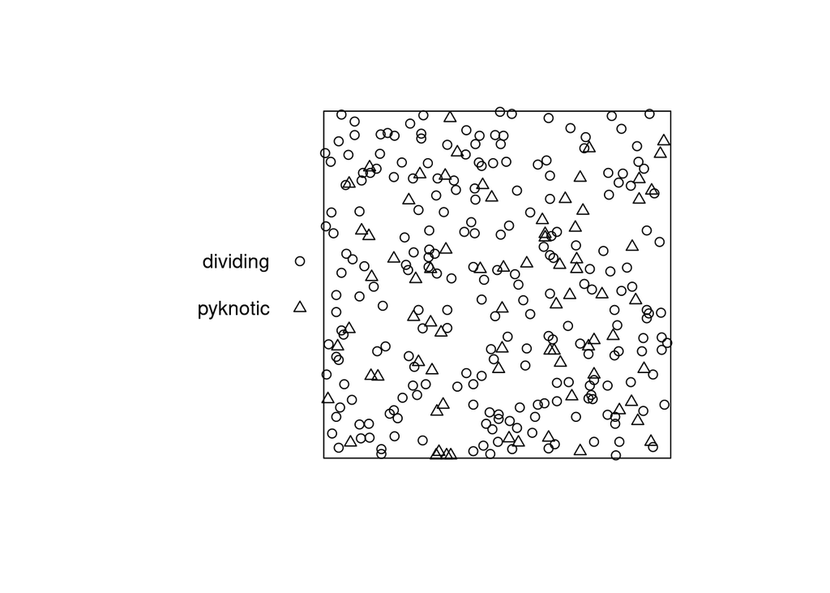

   ```r
   plot(hamster, main = "")
   ```

2. plot the pattern again, changing the colours and symbols used to represent the two types of cells;

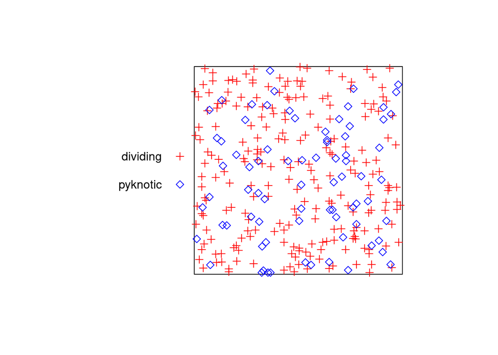

   ```r
   plot(hamster, main = "", cols = c("red", "blue"), chars = c(3, 5))
   ```

3. plot the patterns of pyknotic and dividing cells separately using `plot(split(hamster))`.

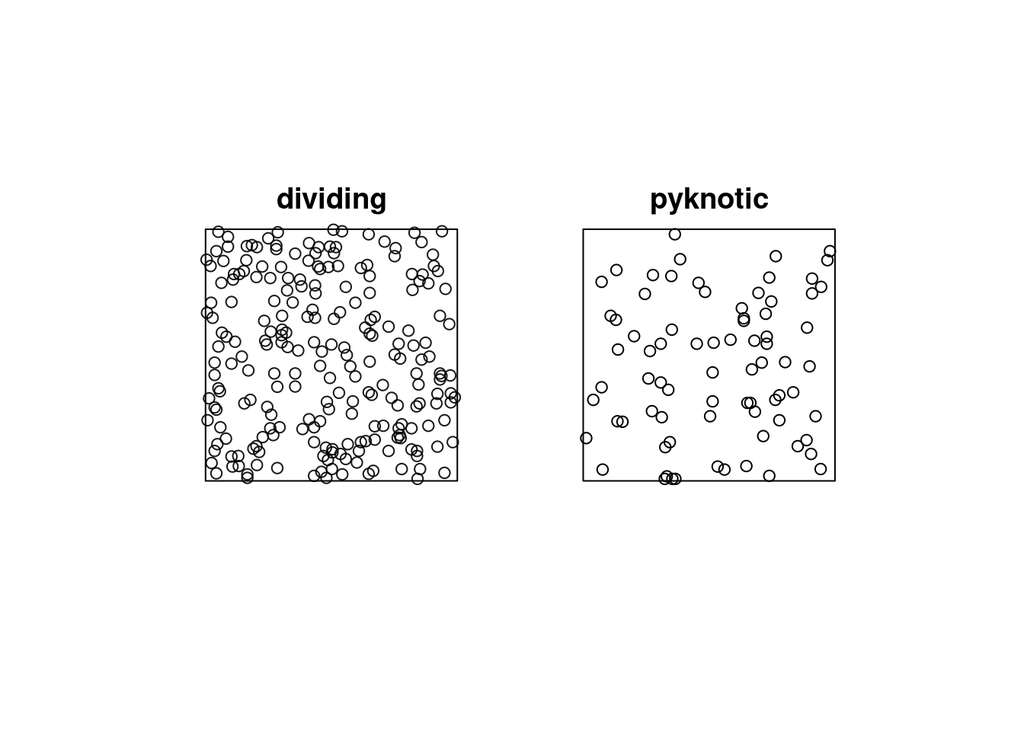

   ```r
   plot(split(hamster), main = "")
   ```

4. use `relrisk` to perform cross-validated bandwidth selection and computation of the relative intensity of pyknotic cells.

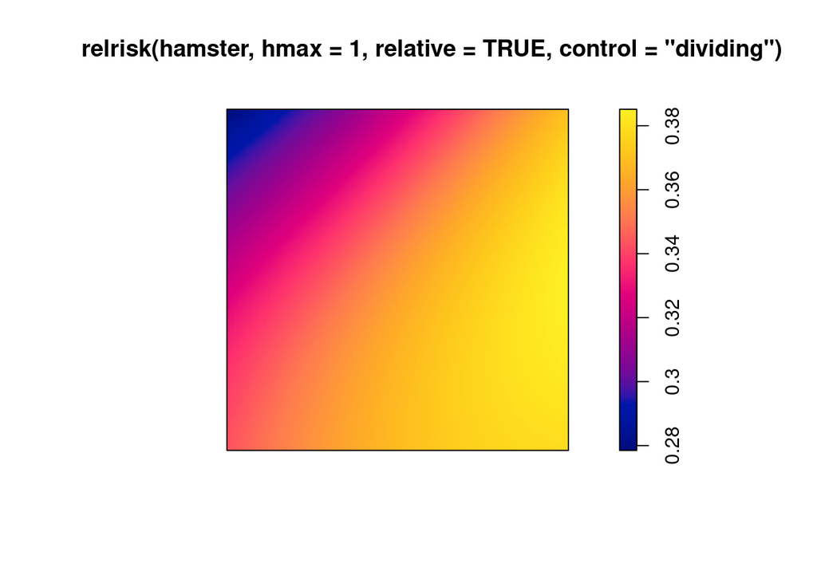

   ```r
   plot(relrisk(hamster, hmax = 1, relative = TRUE, control = "dividing"))
   ```

### Exercise 5

The `bei` dataset gives the locations of trees in a survey area with additional covariate information in a list `bei.extra`.

1. Assign the elevation covariate to a variable `elev` by typing

   ```r
   elev <- bei.extra$elev
   ```

2. Plot the trees on top of an image of the elevation covariate.

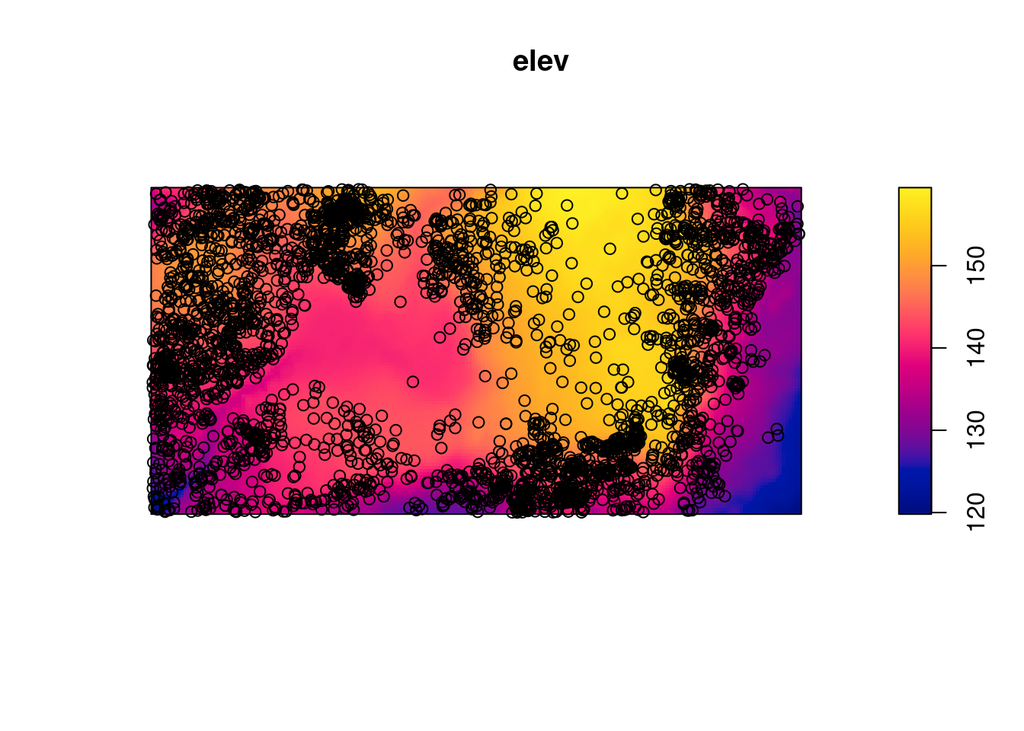

   ```r
   plot(elev)
   plot(bei, add = TRUE, col = "black")
   ```

3. Assume that the intensity of trees is a function $\lambda(u) = \rho(e(u))$ where $e(u)$ is the terrain elevation at location u. Compute a nonparametric estimate of the function $\rho$ and plot it by

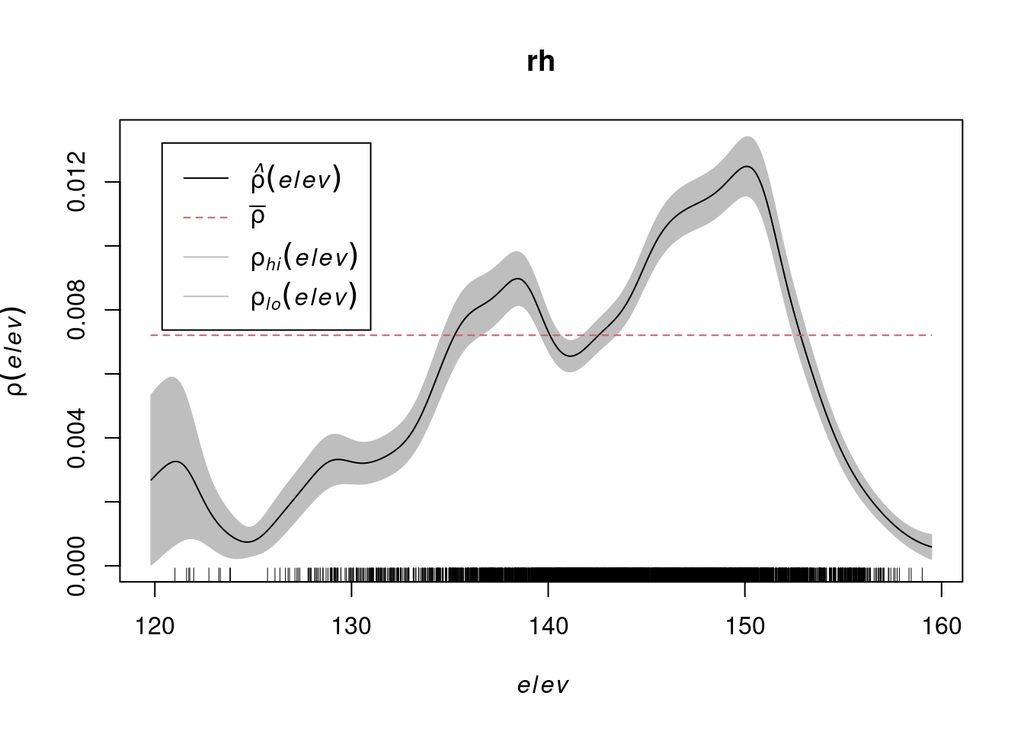

   ```r
   rh <- rhohat(bei, elev)
   plot(rh)
   ```

4. Compute the predicted intensity based on this estimate of $\rho$.

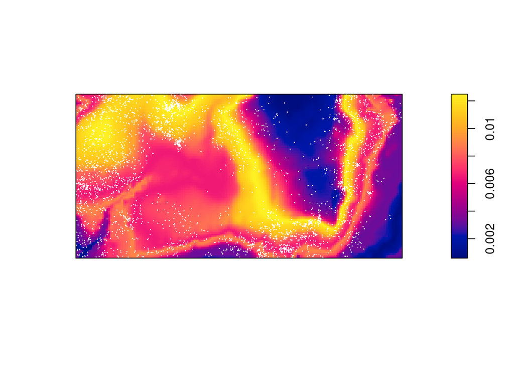

   ```r
   prh <- predict(rh)
   plot(prh, main = "")
   plot(bei, add = TRUE, cols = "white", cex = .2, pch = 16)
   ```

5. Compute a non-parametric estimate of intensity by kernel smoothing, and compare with the predicted intensity above.

   The kernel density estimate of the points is computed and plotted with the following code:

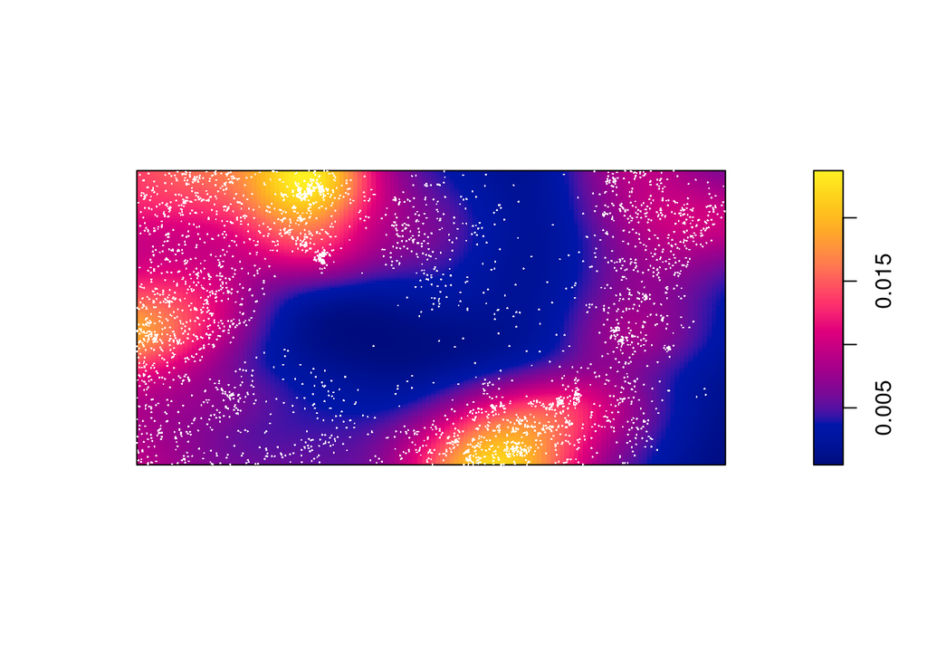

   ```r
   dbei <- density(bei, sigma = bw.scott)
   plot(dbei, main = "")
   plot(bei, add = TRUE, cols = "white", cex = .2, pch = 16)
   ```

   Which seems to be quite different form the predicted intentisty.
6. Bonus info: To plot the two intensity estimates next to each other you collect the estimates as a spatial object list (`solist`) and plot the result (the estimates are called `pred` and `ker` below):

   ```r
   l <- solist(pred, ker)
   plot(l, equal.ribbon = TRUE, main = "",
        main.panel = c("rhohat prediction", "kernel smoothing"))
   ```

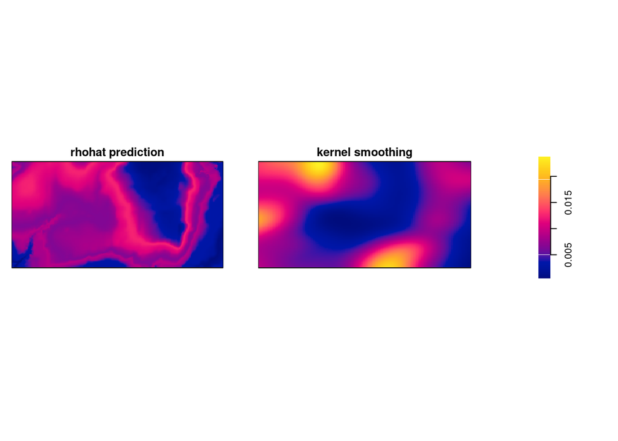

   ```r
   l <- solist(prh, dbei)
   plot(l, equal.ribbon = TRUE, main = "",
        main.panel = c("rhohat prediction", "kernel smoothing"))
   ```